# SciPy

[figure not shown]

- Baut auf NumPy auf
- Kann numerisch integrieren, DGLs lösen, optimieren, minimieren, …
- Enthält auch physikalische Konstanten und wichtige mathematische Funktionen

```python
import numpy as np
x = [2,5,7]
```

```python
# standard error of the mean
from scipy.stats import sem
sem(x)
```

```
1.4529663145135578
```

```python
# physical constants
import scipy.constants as const
const.epsilon_0
```

```
8.854187817620389e-12
```

```python
# convert temperatures:
print(const.convert_temperature(100,'c','K'))
print(const.convert_temperature(100,'kelvin','Celsius'))
```

```
373.15
-173.15
```

```python
# convert angles:
print(np.rad2deg(np.pi))
print(np.deg2rad(90))
```

```
180.0
1.57079632679
```

```python
# more constants (including units and errors)!
list(const.physical_constants.items())[:10]
```

```
[('Wien displacement law constant', (0.0028977685, 'm K', 5.1e-09)),
 ('atomic unit of 1st hyperpolarizablity',
  (3.20636151e-53, 'C^3 m^3 J^-2', 2.8e-60)),
 ('atomic unit of 2nd hyperpolarizablity',
  (6.2353808e-65, 'C^4 m^4 J^-3', 1.1e-71)),
 ('atomic unit of electric dipole moment', (8.47835309e-30, 'C m', 7.3e-37)),
 ('atomic unit of electric polarizablity',
  (1.648777274e-41, 'C^2 m^2 J^-1', 1.6e-49)),
 ('atomic unit of electric quadrupole moment',
  (4.48655124e-40, 'C m^2', 3.9e-47)),
 ('atomic unit of magn. dipole moment', (1.8548019e-23, 'J T^-1', 1.6e-30)),
 ('atomic unit of magn. flux density', (235051.755, 'T', 0.0014)),
 ('deuteron magn. moment', (4.33073482e-27, 'J T^-1', 3.8e-34)),
 ('deuteron magn. moment to Bohr magneton ratio',
  (0.0004669754567, '', 5e-12))]
```

### Achtung

Wenn solche Konstanten genutzt werden, muss das korrekt mitgeteilt, also zitiert werden. Darauf gehen wir nächste Woche im LaTeX-Workshop ein :-)

(Quelle hier: *python-scipy*)

```python
const.physical_constants["proton mass"]
# value, unit, error
```

```
(1.672621898e-27, 'kg', 2.1e-35)
```

## Fitten

Oft möchte man eine Funktion, zum Beispiel eine Erwartung aus der Theorie, an die gemessenen Werte anpassen. Dies nennt man Fit.

```python
# fit arbitrary functions
from scipy.optimize import curve_fit

x, y = np.genfromtxt('example_data.txt', unpack=True)

def f(x, a, b):
    return a * x + b

params, covariance_matrix = curve_fit(f, x, y)

errors = np.sqrt(np.diag(covariance_matrix))

print('a =', params[0], '±', errors[0])
print('b =', params[1], '±', errors[1])
```

```
a = 4.97742635551 ± 0.0214390034102
b = 0.070084504726 ± 0.123809150457
```

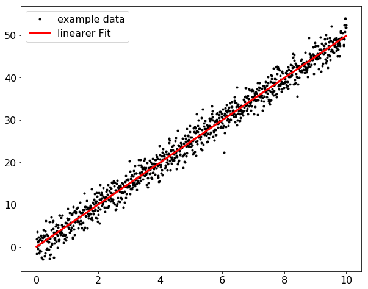

```python
# prepare plot
%matplotlib inline
import matplotlib.pyplot as plt
plt.rcParams['figure.figsize'] = (10, 8)
plt.rcParams['font.size'] = 16


x_plot = np.linspace(0, 10)

plt.plot(x, y, 'k.', label="example data")
plt.plot(x_plot, f(x_plot, *params), 'r-', label='linearer Fit', linewidth=3)
plt.legend(loc="best")
```

Da ein Fit mit `curve_fit()` intern ein Minimierungsalgorithmus ist, hängt  
das Ergebnis unter Umständen von den Anfangsbedingungen ab.

Fit einer komplexeren Funktion: Sigmoidfunktion (Ähnlich zum `tanh`)

$$ f(x; a, b, c) = \frac{a}{1 + \exp(-(x-b))} + c$$

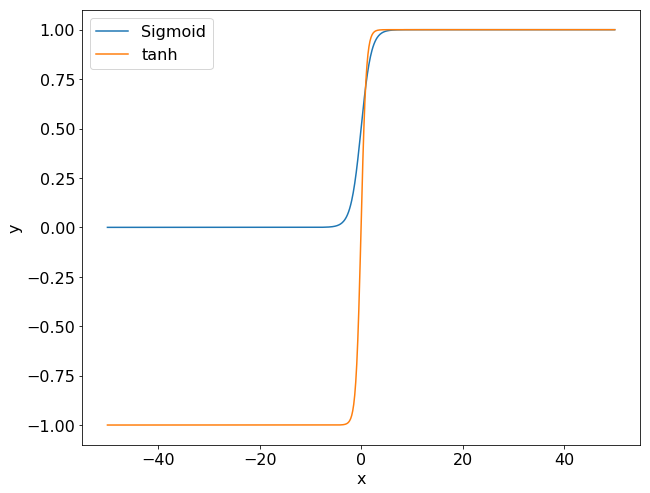

```python
def sigmoid(x, a, b, c):
    y = a / (1 + np.exp(-(x-b))) + c
    return y

x_plot = np.linspace(-50, 50, 1000)

plt.xlabel('x')
plt.ylabel('y')

plt.plot(x_plot, sigmoid(x_plot, 1, 0, 0), label="Sigmoid")
plt.plot(x_plot, np.tanh(x_plot), label="tanh")
plt.legend()
```

Die Messwerte aus einem Praktikumsversuch:

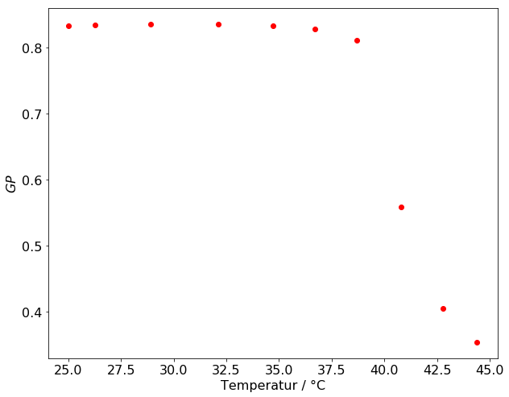

```python
x, y = np.loadtxt('fit_data_with_init_values.txt', unpack=True)

plt.plot(x, y, 'ro', label=r'Messwerte')

plt.xlabel('Temperatur / °C')
plt.ylabel('$GP$')
```

Ein einfacher Fit wie oben funktioniert hier nicht so gut:

```python
params, covariance_matrix = curve_fit(sigmoid, x, y)

errors = np.sqrt(np.diag(covariance_matrix))

print('a =', params[0], '±', errors[0])
print('b =', params[1], '±', errors[1])
```

```
a = -307.055916178 ± inf
b = 1.0 ± inf
```

Schaut man sich die berechnete Ausgleichskurve an sieht man auch,  
dass das nicht stimmen kann:

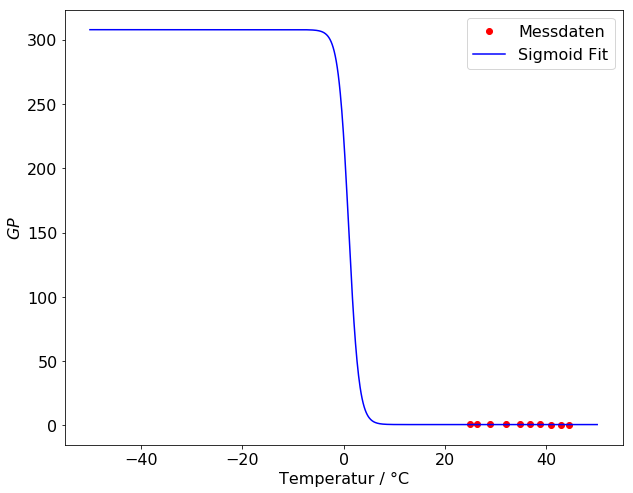

```python
plt.xlabel('Temperatur / °C')
plt.ylabel('$GP$')

plt.plot(x, y, 'ro', label='Messdaten')
plt.plot(x_plot, sigmoid(x_plot, *params), "b-", label=r'Sigmoid Fit')

plt.legend(loc='best')
```

**Was macht man jetzt?**  
Bei solchen Fragen hilft die Dokumentation der Pythonmodule (hier: scipy) oder *Stackoverflow* weiter.  
Folgendes *Google-Muster* ist ein guter Anfang (beachte englische Sprache):

```
python <module-name> <function-name> <What went wrong?>
```

Also in diesem Fall: `python scipy curve_fit fails`

Damit dieser Fit funktioniert müssen die Startwerte für den internen  
Minimierungsalgorithmus angepasst werden.  
Aus der Dokumentation/Stackoverflow wissen wir jetzt, dass man mit dem  
*keyword argument* `p0` (Standardwert is `p0=(1,1,1)`) die Startwerte einstellt:

```python
params, covariance_matrix = curve_fit(sigmoid, x, y, p0=(-1, 40, 1))

errors = np.sqrt(np.diag(covariance_matrix))

print('a =', params[0], '±', errors[0])
print('b =', params[1], '±', errors[1])
```

```
a = -0.493935581363 ± 0.0138538297848
b = 40.6675535294 ± 0.136960842835
```

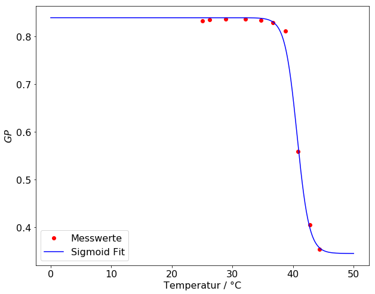

```python
plt.xlabel('Temperatur / °C')
plt.ylabel('$GP$')

x_plot = np.linspace(0, 50, 1000)

plt.plot(x, y, 'ro', label='Messwerte')
plt.plot(x_plot, sigmoid(x_plot, *params), "b-", label='Sigmoid Fit')

plt.legend(loc='best')
```

Zum Vergleich der beiden Anfangswerte (seeds) kann man sich die einmal ansehen  
und mit den angepassten Parametern vergleichen:

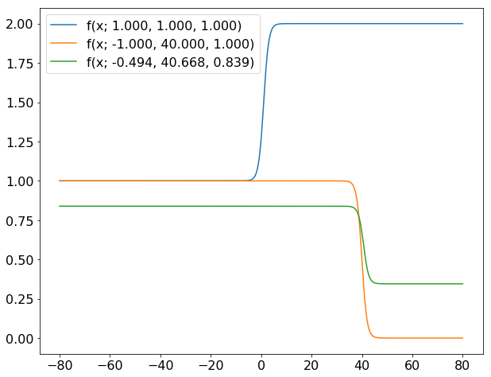

```python
default_seed = (1,1,1)
good_seed = (-1,40,1)

parameter = [default_seed, good_seed, params]

x_plot = np.linspace(-80, 80, 1000)

for p in parameter:
    plt.plot(x_plot, sigmoid(x_plot, *p),  label="f(x; {0:0.3f}, {1:0.3f}, {2:0.3f})".format(*p))

plt.legend()
```

Die richtigen Startwerte findet man entweder durch

1. *trial and error* => einfach ausprobieren bis es klappt
2. *nachdenken* => siehe unten

$$ f(x; a, b, c) = \frac{a}{1 + \exp(-(x-b))} + c$$

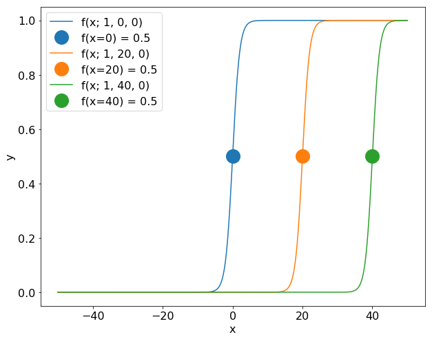

```python
B = [0, 20, 40]

x_plot = np.linspace(-50, 50, 1000)

plt.xlabel('x')
plt.ylabel('y')


for b in B:

    line = plt.plot(x_plot, sigmoid(x_plot, 1, b, 0),  label=f"f(x; 1, {b}, 0)")
    plt.plot(b, sigmoid(b, 1, b, 0), "o", color=line[0].get_color(), ms=20, label=f"f(x={b}) = {sigmoid(b, 1, b, 0)}")


plt.legend()
```

Der Parameter $b$ gibt den $x$-Wert an bei dem die Funktion auf die Hälfte des Maximums abgefallen ist.  
Bei den Messwerten oben ist die Stelle ungefähr bei $x=40$ also ist `b=40` ein guter Startwert.